# Social Media Mining with R

# Word Count Plot - Facebook

- The bar charts is made `word_count_plot` function.
- The two arguments required by the functions are
  - `tokenized dataset`
  - `minimum frequency`

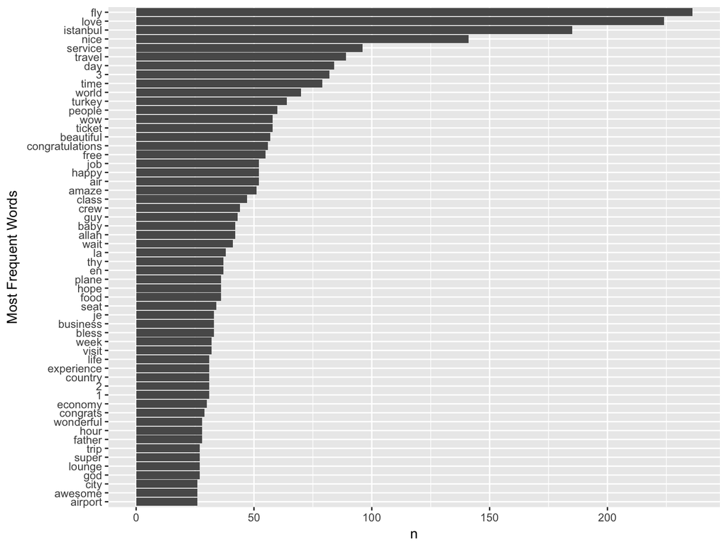

```r
word_count_plot("tokens_count_300", 25)
```

- The technique helps to figure out the frequency of one word relative to other related word.
- Following words are near to each other
  - “wow”
  - “beautiful”
  - “happy”
  - “amaze”
- The equal length of bar charts show similar frequencies of above sentiments.

# Word Count Plot - TripAdvisor

- The bar charts is made `word_count_plot` function.
- The two arguments required by the functions are
  - `tokenized dataset`
  - `minimum frequency`
- The word with frequency less than the minimum frequency will not be plotted in the bar chart.

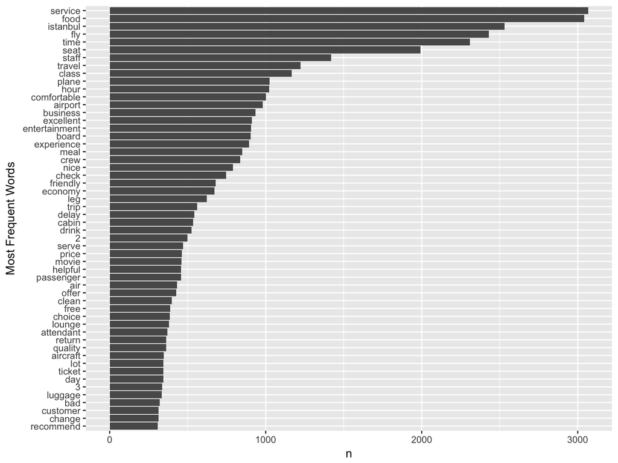

```r
word_count_plot("TA_tokens_count_6846", 300)
```